# Zhang-m5

Luoben Zhang

11/22/2019

## 2. Matrix Representation

```r
n <- 1000
d <- runif(n*n)
d[d < 0.80] <- NA
d <- matrix(d,nrow=n,ncol=n)
diag(d) <- NA # no self-loops
d[upper.tri(d)] = t(d)[upper.tri(d)]

AdjMatrix2List <- function (d) {
  head<-c()
  tail<-c()
  weight<-c()
  a<-0
  for(i in 1:n) {
    for(j in 1:n){
      if(!is.na(d[i,j])){
        a<-a+1
        head[a]<-i
        tail[a]<-j
        weight[a]<-d[i,j]
      }
    }
  }
  b<-cbind(head,tail, weight)
}
ds <- AdjMatrix2List(d)
```

```r
str(d)
```

```
##  num [1:1000, 1:1000] NA 0.873 NA 0.946 0.912 ...
```

```r
str(ds)
```

```
##  num [1:200636, 1:3] 1 1 1 1 1 1 1 1 1 1 ...
##  - attr(*, "dimnames")=List of 2
##   ..$ : NULL
##   ..$ : chr [1:3] "head" "tail" "weight"
```

```r
head(ds)
```

```
##      head tail    weight
## [1,]    1    2 0.8731795
## [2,]    1    4 0.9459925
## [3,]    1    5 0.9115088
## [4,]    1    7 0.8882128
## [5,]    1   32 0.9788768
## [6,]    1   34 0.9678812
```

## 3. Euclidean Minimum Spanning Tree

### 3.1

```r
n <- 50
x <- round(runif(n)*1000)
y <- round(runif(n)*1000)
#plot(x,y,pch=16)

q <- c()
for (i in 1:n){
  for (j in 1:n){
    q <- append(q, sqrt((x[j]-x[i])^2+(y[j]-y[i])^2))
  }
}
matrix3 <- matrix(q, nrow=50)
```

#### It is a complete graph. By definition, a complete graph is a simple undirected graph in which every pair of distinct vertices is connected by a unique edge. What we have done satisfies the definition.

### 3.2

```r
p <- AdjMatrix2List(matrix3)
v <- c()
for (i in 1:nrow(p)){
  if (p[i,1] != p[i,2]){
    v <- append(v, p[i,2])
  }
}
dimnames(v) <- NULL

v1 <- matrix(1:50, ncol =1)
v <- matrix(v, ncol = 49, byrow = TRUE)
ds <- cbind(v1,v)
```

### 3.3

```r
ds.mst <- msTreePrim(1:n, AdjMatrix2List(matrix3)) # nodes, arcs
str(ds.mst)
```

```
## List of 4
##  $ tree.nodes : num [1:50] 1 12 11 2 29 25 10 16 30 31 ...
##  $ tree.arcs  : num [1:49, 1:3] 1 1 12 2 29 25 11 16 30 30 ...
##   ..- attr(*, "dimnames")=List of 2
##   .. ..$ : NULL
##   .. ..$ : chr [1:3] "ept1" "ept2" "weight"
##  $ stages     : num 49
##  $ stages.arcs: num [1:49] 1 2 3 4 5 6 7 8 9 10 ...
```

### 3.4

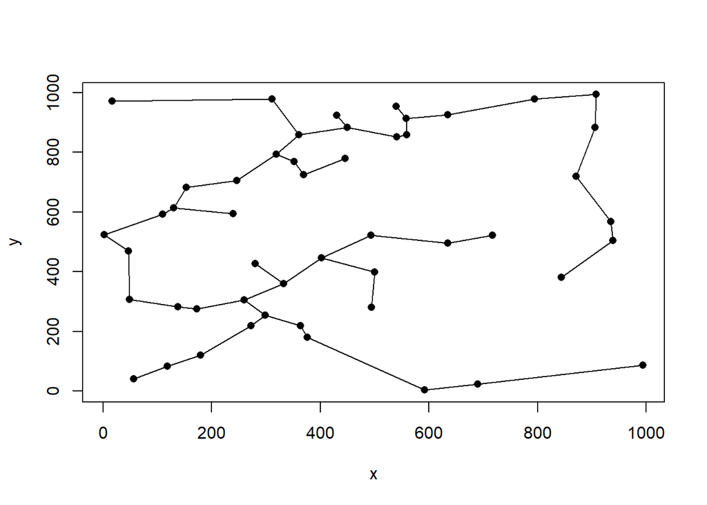

```r
plot.mst <- function(arcList){
  for (i in 1:nrow(arcList)){
    segments(x0=x[arcList[i,1]], y0=y[arcList[i,1]], x1=x[arcList[i,2]], y1=y[arcList[i,2]])
  }
}

plot(x,y,pch=16)
plot.mst(ds.mst$tree.arcs)
```

## 4. Hostile Agents

#### 1. This is a graph optimization problem simply because we can visualize the problem. And furthermore, we should use minimum spanning tree(MST) to finally solve it after we visualize it.

#### 2. We can create a adjacency matrix just like what we have done above, we create a n*n matrix, and each elements of this matrix represent the probability(Pij) that message passed between these agents will fall into hostile hands.

#### 3. From my opinion, we should use Kruskal algorithm to slove this problem.

#### 4. It takes O(ElgE) to run this algorithm. I think it is more efficient to use for this problem.

## 5. Project Scheduling

### 5.4 Earliest Start Times(ES)

```r
s.labels <- c('a','b','c','d','e','f','g','h','i','j')
s.nodes <- c(90,15,5,20,21,25,14,28,30,45)
#s.nodes1 <- c('-90','-15','-5','-20','-21','-25','-14','-28','-30','-45')

n <- 13
d1 <- NA
d1 <- matrix(d1,nrow=n,ncol=n)
d1[1,2] <- -90; d1[1,9] <- -90; d1[1,6] <- -90;
d1[2,3] <- -15;
d1[3,7] = -5;
d1[7,4] = -14;
d1[4,10] =-20; d1[4,8]=-20;
d1[4,5] <- -20;
d1[9,10]=-30;
d1[6,7]= -25;
d1[10,11] = -45
d1[5,12] = -21
d1[8,13] = -28
diag(d1) <- NA
ak <- AdjMatrix2List(d1)

zlb <- getShortestPathTree(1:13,ak,algorithm = "Bellman-Ford", directed = TRUE)
```

```
##
##  Shortest path tree
##  Algorithm: Bellman-Ford
##  Stages:  12 | Time:  0.01
##  ------------------------------
##       head     tail    weight
##          1        2       -90
##          1        6       -90
##          1        9       -90
##          2        3       -15
##          4        5       -20
##          4        8       -20
##          4       10       -20
##          5       12       -21
##          6        7       -25
##          7        4       -14
##          8       13       -28
##         10       11       -45
##  ------------------------------
##                    Total = -478
##
##  Distances from source:
##  ------------------------------
##     source     node  distance
##          1        2       -90
##          1        3      -105
##          1        4      -129
##          1        5      -149
##          1        6       -90
##          1        7      -115
##          1        8      -149
##          1        9       -90
##          1       10      -149
##          1       11      -194
##          1       12      -170
##          1       13      -177
##  ------------------------------
```

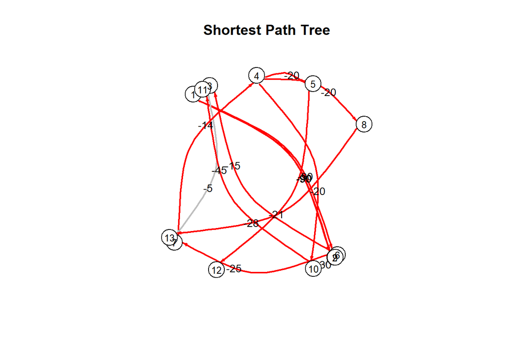

### 5.5

```r
CT <- as.Date("2019-11-01")-min(zlb$distances)
print(paste("Earliest Overall Project Completion Time will be:", CT))
```

```
## [1] "Earliest Overall Project Completion Time will be: 2020-05-13"
```

### 5.6

#### 90 days after will be the earliest finish date for A

#### 90+15=105 days after will be the earliest finish date for B

#### 105+5=110 days after will be the earliest finish date for C

#### 129+20=149 days after will be the earliest finish date for D

#### 149+21=170 days after will be the earliest finish date for E

#### 90+25=115 days after will be the earliest finish date for F

#### 115+14=129 days after will be the earliest finish date for G

#### 149+28=177 days after will be the earliest finish date for H

#### 90+30=120 days after will be the earliest finish date for I

#### 149+45=194 days after will be the earliest finish date for J

```r
EF <- c(90, 105, 110, 149, 170, 115, 129, 177, 120, 194)

n <- 11
d2 <- NA
d2 <- matrix(d2,nrow=n,ncol=n)
d2[11, 5] <- 0
d2[11,8] <- 0
d2[11,10] <- 0
d2[5,4] <- -21
d2[8,4] <- -28
d2[4,7] <- -20
d2[10,4] <- -45
d2[10,9] <- -45
d2[9,1] <- -30
d2[7,6] <- -14
d2[7,3] <- -14
d2[6,1] <- -25
d2[3,2] <- -5
d2[2,1] <- -15


diag(d2) <- NA
ak1 <- AdjMatrix2List(d2)
zlb1 <- getShortestPathTree(1:11,ak1,algorithm = "Bellman-Ford", source.node = 11, directed = TRUE)
```

```
##
##  Shortest path tree
##  Algorithm: Bellman-Ford
##  Stages:  10 | Time:  0
##  ------------------------------
##       head     tail    weight
##          3        2        -5
##          4        7       -20
##          6        1       -25
##          7        3       -14
##          7        6       -14
##         10        4       -45
##         10        9       -45
##         11        5         0
##         11        8         0
##         11       10         0
##  ------------------------------
##                    Total = -168
##
##  Distances from source:
##  ------------------------------
##     source     node  distance
##         11        1      -104
##         11        2       -84
##         11        3       -79
##         11        4       -45
##         11        5         0
##         11        6       -79
##         11        7       -65
##         11        8         0
##         11        9       -45
##         11       10         0
##  ------------------------------
```

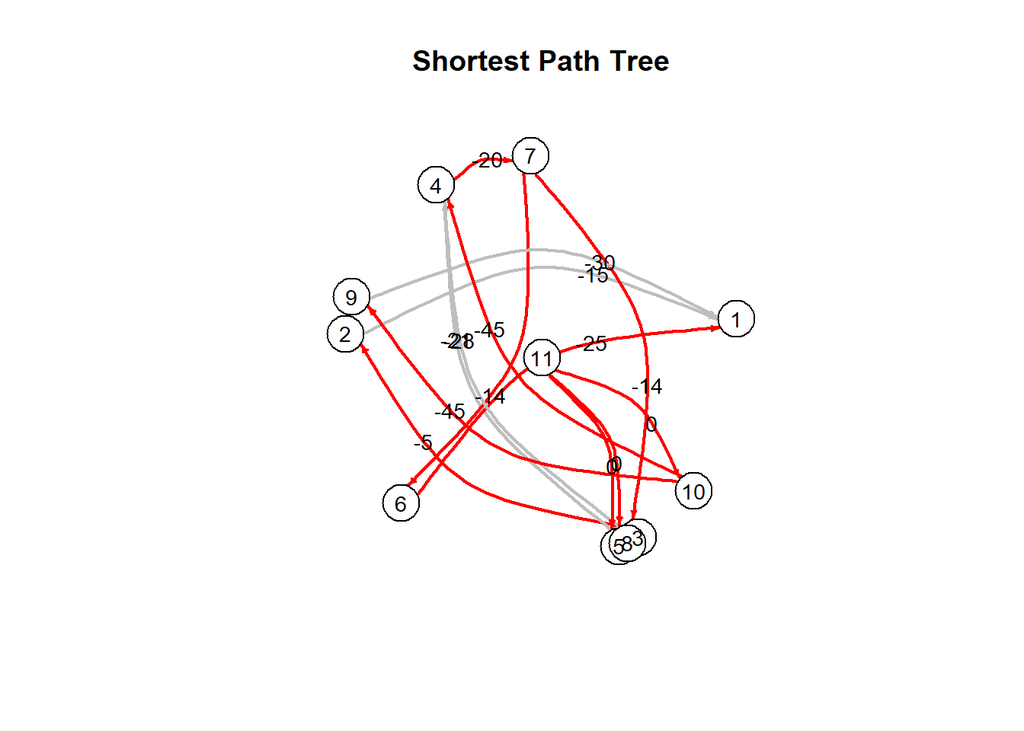

### 5.7

```r
LF <- c(194 + zlb1$distances)
LF <- LF[1:10]
```

#### 90 days will be the latest finish times for A

#### 110 days will be the latest finish times for B

#### 115 days will be the latest finish times for C

#### 149 days will be the latest finish times for D

#### 194 days will be the latest finish times for E

#### 115 days will be the latest finish times for F

#### 129 days will be the latest finish times for G

#### 194 days will be the latest finish times for H

#### 149 days will be the latest finish times for I

#### 194 days will be the latest finish times for J

### 5.8

```r
LS <- LF - s.nodes
```

#### 0 days will be the latest start times for A

#### 95 days will be the latest start times for B

#### 110 days will be the latest start times for C

#### 129 days will be the latest start times for D

#### 173 days will be the latest start times for E

#### 90 days will be the latest start times for F

#### 115 days will be the latest start times for G

#### 166 days will be the latest start times for H

#### 119 days will be the latest start times for I

#### 149 days will be the latest start times for J

### 5.9

```r
slack <- LF - EF
```

#### 1. B,C,E,H,I have scheduling flexibility

#### 2. A,D,F,G,J are on the critical path